# Exploring the Relationship Between Poverty and Air Quality in the U.S.

Karina Lakhani & Tyrone Bartholomew

GitHub Pages Link: https://kllakhani.github.io/

For our project, we decided to study the relationship between air quality and poverty levels in counties across the United States. Our main question is whether poorer counties tend to experience worse air quality. We want to know if there is a meaningful correlation between a county’s poverty rate and the pollution that people living there are exposed to.

This topic fits well with both of our academic interests. From a data and technology perspective, it gives us a chance to work with real datasets that require cleaning, merging, and careful analysis. On the environmental side, it connects directly to issues of public health and environmental justice. Air quality is not only an environmental concern but also a social one because poor air can cause asthma, heart disease, and other long-term health problems. If those health risks fall more heavily on low-income communities, it raises important questions about fairness and how resources are distributed in the United States.

We are also motivated by what has already been documented in environmental justice research. Many studies have found that low-income neighborhoods and historically marginalized communities often live closer to highways, factories, and other pollution sources. By looking at national data from 2023, we want to see whether these patterns still show up and how strong the relationship is when we compare poverty levels and air quality directly.

For our analysis, we chose 2023 because it is the most recent year where the datasets we are using overlap. Our plan is to clean each dataset, fix any missing or inconsistent entries, and then merge everything by county. Once we have a unified dataset, we will remove any overlapping variables that might confuse the results. After that, we will visualize the data and run some statistical tests to see if any patterns stand out.

Our goal is to find out whether counties with higher poverty rates tend to have worse air quality. If we do find a clear trend, it would support the idea that environmental burdens are not evenly shared. It would also show that pollution affects certain communities more than others, often in ways that go unnoticed. By focusing on this connection, we hope to highlight how environmental and economic issues are linked and why it is important to consider both when thinking about public health and policy.

## Hypothesis

Based on past environmental justice research, our initial hypothesis was that higher-poverty counties will have slightly worse air quality, especially for pollutants like NO₂ that are linked to traffic and industry.

We didn’t expect a perfect linear trend, but we hypothesized that there might be at least a small positive relationship.

## Research Questions

1. Is there a correlation between a county’s poverty rate and its air quality?
2. Do certain regions show stronger relationships between poverty and pollution?
3. Are counties with higher poverty exposed to worse pollutants like ozone or NO₂?

## Datasets

USDA County-Level Data Sets (2023)- [USDA County-Level Data Sets](https://www.ers.usda.gov/data-products/county-level-data-sets/county-level-data-sets-download-data)

## Extraction, Transform, and Load (ETL)

Before analyzing anything, we needed to bring the two datasets into a consistent format so they could actually work together. The ETL step let us load the files, clean up the structure, and get everything aligned at the county level. Once the data was organized and usable, we were able to move on to exploring patterns between poverty and air quality.

```python
import pandas as pd, numpy as np, re
import seaborn as sns, matplotlib.pyplot as plt
plt.style.use('seaborn-v0_8-whitegrid'); sns.set_palette('crest')
pd.set_option('display.max_columns', 120)

from google.colab import drive
drive.mount('/content/drive')
```

Here we import the main libraries we need for the project and connect to Google Drive. We use pandas and numpy for data cleaning and analysis, and seaborn and matplotlib to make visualizations. We also set a simple plotting style and increase the number of columns pandas will show so it is easier to look at wide tables.

Finally, we mount Google Drive with drive.mount('/content/drive') so the notebook can access the CSV and Excel files we saved there.

```python
POVERTY_PATH = '/content/drive/MyDrive/usda_poverty_2023.csv'
AIR_PATH     = '/content/drive/MyDrive/ctyfactbook2023.xlsx'

poverty = pd.read_csv(POVERTY_PATH)

air = pd.read_excel(AIR_PATH, skiprows=2)
```

In this step, we loaded both of our datasets into Python so we could start working with them. The poverty data was stored as a CSV file, and the air quality data was stored as an Excel file. We used pd.read_csv() for the CSV file and pd.read_excel() for the Excel file.

We also used skiprows=2 when loading the air quality dataset because the first two rows of the Excel file were extra header information that did not contain actual data. Skipping those rows gives us a clean dataframe with the correct column names and values.

Loading the datasets is the first step in any analysis, and it allows us to explore, clean, and eventually merge the data so we can compare air quality and poverty levels across U.S. counties.

```python
def clean_cols(df):
    return (df.columns.astype(str)
            .str.normalize('NFKD').str.encode('ascii','ignore').str.decode('ascii')
            .str.strip().str.lower()
            .str.replace(r'[^a-z0-9]+','_', regex=True)
            .str.strip('_'))

poverty.columns = clean_cols(poverty)
air.columns     = clean_cols(air)

print('poverty cols:', poverty.columns.tolist())
print('air cols (first 20):', air.columns.tolist()[:20])
```

```
poverty cols: ['county', 'state', 'povertyrate']
air cols (first 20): ['state', 'county', 'county_fips_code', '2010_population', 'co_8_hr_ppm', 'pb_3_mo_g_m3', 'no2_am_ppb', 'no2_1_hr_ppb', 'o3_8_hr_ppm', 'pm10_24_hr_g_m3', 'pm2_5_wtd_am_g_m3', 'pm2_5_24_hr_g_m3', 'so2_1_hr_ppb']
```

Here we defined a helper function called clean_cols() that makes all the column names consistent across both datasets. It converts the names to lowercase, removes special characters, replaces spaces with underscores, and strips out anything that might cause problems when merging the data later.

After defining the function, we applied it to both the poverty and air quality dataframes. This step is important because both datasets came from different sources, and having clean, standardized column names makes the rest of the analysis easier and prevents merge errors.

The printed output shows the cleaned columns for each dataset so we can confirm everything looks correct.

```python
def norm_name(s):
    if pd.isna(s): return s
    s = str(s).strip()
    s = re.sub(r'\s+(county|parish|borough|census area|city and borough)$', '', s, flags=re.I)
    s = s.replace('St. ', 'Saint ')
    return s

poverty = poverty.rename(columns={'povertyrate':'poverty_rate'})
for c in ['county','state']:
    if c in poverty.columns:
        poverty[c] = poverty[c].astype(str).map(norm_name)

for c in ['county','state']:
    if c in air.columns:
        air[c] = air[c].astype(str).map(norm_name)

air_keep = [c for c in ['state','county','county_fips_code','pm2_5_wtd_am_ug_m3','o3_8_hr_ppm','no2_am_ppb'] if c in air.columns]
air = air[air_keep].copy()
air = air.rename(columns={'county_fips_code':'fips'})

if 'fips' in air.columns:
    air['fips'] = (
        air['fips']
        .astype(str)
        .str.replace('.0', '', regex=False)
        .str.zfill(5)
    )

poverty.head(), air.head()
```

```
(             county      state  poverty_rate
 0           Orleans  Louisiana          23.4
 1  East Baton Rouge  Louisiana          17.2
 2            Harris      Texas          16.1
 3            Dallas      Texas          15.8
 4            Travis      Texas          12.9,
      state   county   fips o3_8_hr_ppm no2_am_ppb
 0  Alabama  Baldwin  01003       0.065         ND
 1  Alabama     Clay  01027          ND         ND
 2  Alabama  Colbert  01033          ND         ND
 3  Alabama   DeKalb  01049       0.066         ND
 4  Alabama   Elmore  01051       0.061         ND)
```

Here we cleaned the county and state names in both datasets so they would match when we merge them later. The norm_name() function removes endings like “County” or “Parish” and fixes small formatting differences, such as turning “St.” into “Saint.” We also renamed the poverty column to poverty_rate to make it clearer. After that, we applied the name-cleaning function to both the poverty data and the air quality data. For the air quality dataset, we selected only the columns we needed, including the pollutant measures and the FIPS code, then formatted the FIPS code so it always shows up as a standard five-digit string. This step helps ensure the datasets line up properly and that we only carry the variables needed for the rest of the analysis.

```python
df = poverty.merge(air, on=['state','county'], how='inner')
print('merged shape:', df.shape)
df.head()
```

```
merged shape: (20, 6)
```

|  | county | state | poverty_rate | fips | o3_8_hr_ppm | no2_am_ppb |
| --- | --- | --- | --- | --- | --- | --- |
| 0 | Orleans | Louisiana | 23.4 | 22071 | ND | 8 |
| 1 | East Baton Rouge | Louisiana | 17.2 | 22033 | 0.074 | 6 |
| 2 | Harris | Texas | 16.1 | 48201 | 0.09 | 18 |
| 3 | Dallas | Texas | 15.8 | 48113 | 0.08 | 9 |
| 4 | Travis | Texas | 12.9 | 48453 | 0.074 | 13 |

Here we merged the poverty data and the air quality data using the state and county columns as our matching keys. We used an inner merge so the final dataframe only includes counties that appear in both datasets. This gives us one combined table that includes poverty rates, pollutant levels, and FIPS codes for the same locations. After merging, we printed the shape to confirm how many counties matched and previewed the first few rows to make sure everything lined up correctly.

```python
cols_to_clean = ['o3_8_hr_ppm', 'no2_am_ppb', 'poverty_rate']

for col in cols_to_clean:
    if col in df.columns:
        df[col] = (
            df[col]
            .astype(str)
            .str.strip()
            .replace({'ND': np.nan, 'nan': np.nan, '': np.nan, 'None': np.nan})
        )
        df[col] = pd.to_numeric(df[col], errors='coerce')

df[cols_to_clean].dtypes
```

|  | 0 |
| --- | --- |
| o3_8_hr_ppm | float64 |
| no2_am_ppb | float64 |
| poverty_rate | float64 |

**dtype:** object

Before moving into our visualizations and models, we needed to make sure the pollution variables were actually stored as numeric data. In the raw EPA dataset, some counties use codes like "ND" (meaning “no data”) instead of a number, and that causes problems when we try to plot histograms or run statistical tests.

In this step, we replaced those placeholders with proper missing values (NaN) and then converted the poverty rate, ozone, and NO₂ columns to numeric types. This was the last part of our ETL process and ensured that the dataset is clean and consistent.

## Exploratory Data Analysis (EDA)

With a fully cleaned dataset, we started our exploratory analysis to get a sense of how poverty and pollution vary across counties.

### Poverty Distribution

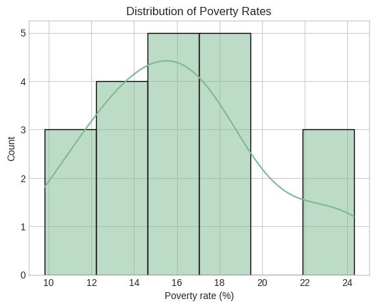

```python
sns.histplot(df['poverty_rate'], kde=True)
plt.title('Distribution of Poverty Rates')
plt.xlabel('Poverty rate (%)')
plt.show()
```

The histogram of poverty rates shows that most counties in this sample have poverty rates between 14% and 18%, with only a few at the higher end (above 20%). The slight right skew suggests that a small number of counties experience significantly higher poverty than the majority, but overall the distribution is fairly concentrated in the midrange.

### Ozone Distribution

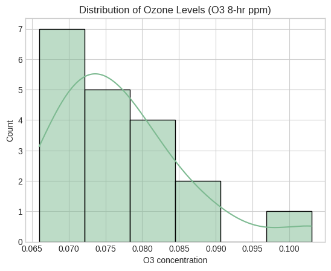

```python
sns.histplot(df['o3_8_hr_ppm'], kde=True)
plt.title('Distribution of Ozone Levels (O3 8-hr ppm)')
plt.xlabel('O3 concentration')
plt.show()
```

Ozone concentrations (O₃ 8-hr ppm) are tightly clustered between 0.07 and 0.09 ppm, showing low variability across counties. This narrow range makes it harder to detect meaningful correlations with other variables like poverty. The skew toward lower ozone values indicates that most counties maintain relatively good air quality for ozone exposure.

### Correlation Heatmap

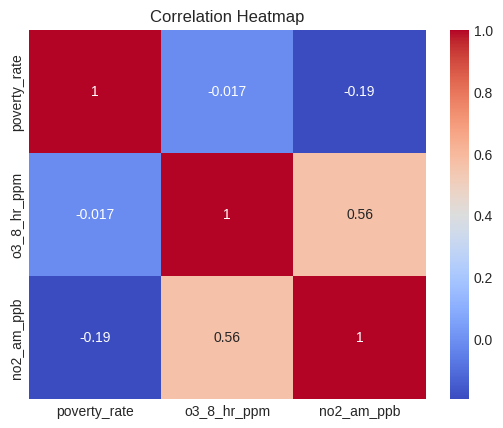

```python
corr = df[['poverty_rate','o3_8_hr_ppm','no2_am_ppb']].apply(pd.to_numeric, errors='coerce').corr()
sns.heatmap(corr, annot=True, cmap='coolwarm')
plt.title('Correlation Heatmap')
plt.show()
```

The heatmap displays Pearson correlation values among poverty rate, ozone levels, and nitrogen dioxide (NO₂). The correlations are weak: poverty vs O₃ (−0.02) and poverty vs NO₂ (−0.19). However, O₃ and NO₂ have a moderate positive relationship (r = 0.56), meaning that areas with higher ozone levels also tend to have higher nitrogen dioxide, both of which are traffic-related pollutants. This pattern aligns with typical urban pollution trends.

### Poverty vs Air Quality (Scatterplots)

#### 1. Ozone Scatterplot

```python
metric_order = ['o3_8_hr_ppm','no2_am_ppb']
metric = next((m for m in metric_order if m in df.columns), None)

print("Using metric:", metric)


df[metric] = (df[metric].astype(str).str.strip()
              .replace({'ND': np.nan, 'nan': np.nan, '': np.nan, 'None': np.nan}))
df[metric] = pd.to_numeric(df[metric], errors='coerce')

df['poverty_rate'] = pd.to_numeric(df['poverty_rate'], errors='coerce')
```

```
Using metric: o3_8_hr_ppm
```

In this step, we set up a list of possible pollutant columns and selected the first one that exists in our merged dataset. Since ozone (o3_8_hr_ppm) was the first available column, that became our metric for this section. After selecting it, we cleaned the values by removing entries like “ND,” “nan,” or empty strings and converting everything to numeric data. We also converted the poverty rate column to numeric so both variables could be used in plots and calculations. This prepares the dataset for analyzing how poverty levels relate to ozone concentration.

```
n = 19
pearson r = -0.017
```

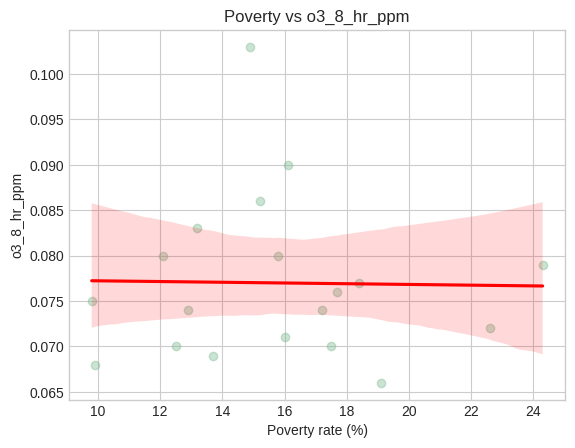

```python
sub = df[['poverty_rate', metric]].dropna()
print(f'n = {len(sub)}')
print('pearson r =', sub.corr().iloc[0,1].round(3))

sns.regplot(data=sub, x='poverty_rate', y=metric, scatter_kws={'alpha':0.4}, line_kws={'color':'red'})
plt.title(f'Poverty vs {metric}'); plt.xlabel('Poverty rate (%)'); plt.ylabel(metric); plt.show()
```

Here we created a smaller dataframe that includes only the poverty rate and the pollutant metric we selected, then dropped any rows with missing values. We printed how many usable counties remained and calculated the Pearson correlation to get a quick sense of the relationship. Finally, we used sns.regplot to graph poverty rate on the x-axis and ozone concentration on the y-axis, along with a regression line. This plot helps visualize whether ozone levels tend to rise or fall as poverty increases, and in our case the relationship appears very weak, which matches the near-zero correlation value.

#### 2. NO₂ Scatterplot

```python
metric = 'no2_am_ppb'
print("Using metric:", metric)


df[metric] = (df[metric].astype(str).str.strip()
              .replace({'ND': np.nan, 'nan': np.nan, '': np.nan, 'None': np.nan}))
df[metric] = pd.to_numeric(df[metric], errors='coerce')

df['poverty_rate'] = pd.to_numeric(df['poverty_rate'], errors='coerce')
```

```
Using metric: no2_am_ppb
```

Here we switched the pollutant metric to nitrogen dioxide (no2_am_ppb) so we could repeat the analysis with a different air quality measure. We cleaned the NO₂ column by removing entries like “ND,” “nan,” or empty strings and converting everything to numeric values. We also ensured the poverty rate column was numeric. This prepares a clean dataset that allows us to compare poverty levels with NO₂ concentrations and run the same correlation and visualization steps as we did with ozone.

```
n = 19
pearson r = -0.194
```

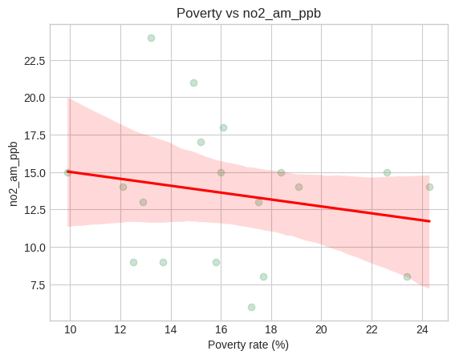

```python
sub = df[['poverty_rate', metric]].dropna()
print(f'n = {len(sub)}')
print('pearson r =', sub.corr().iloc[0,1].round(3))

sns.regplot(data=sub, x='poverty_rate', y=metric, scatter_kws={'alpha':0.4}, line_kws={'color':'red'})
plt.title(f'Poverty vs {metric}'); plt.xlabel('Poverty rate (%)'); plt.ylabel(metric); plt.show()
```

Here we created a smaller dataframe that contains only the poverty rate and the NO₂ metric, then removed any missing values. We printed how many counties had valid NO₂ data and calculated the Pearson correlation to measure the strength of the relationship. Using sns.regplot, we plotted poverty rate against NO₂ concentration and added a regression line to show the overall trend. The correlation is slightly negative, and the line slopes downward, but the relationship is still weak. This suggests that in our dataset, higher poverty does not strongly predict higher NO₂ levels, at least for the counties with available data.

### Air Quality Across Poverty Groups

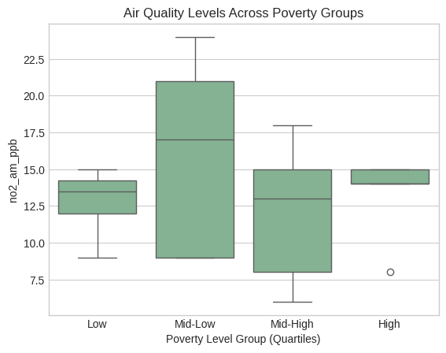

```python
df['poverty_group'] = pd.qcut(df['poverty_rate'], 4, labels=['Low','Mid-Low','Mid-High','High'])

sns.boxplot(data=df, x='poverty_group', y=metric)
plt.title('Air Quality Levels Across Poverty Groups')
plt.xlabel('Poverty Level Group (Quartiles)')
plt.ylabel(metric)
plt.show()
```

## Modeling

### Model 1: Linear Regression (Poverty → NO₂)

#### OLS Regression Table

```python
import statsmodels.api as sm

X = df[['poverty_rate']].astype(float)
X = sm.add_constant(X)

df['no2_am_ppb'] = (df['no2_am_ppb'].astype(str).str.strip()
              .replace({'ND': np.nan, 'nan': np.nan, '': np.nan, 'None': np.nan}))
y = pd.to_numeric(df['no2_am_ppb'], errors='coerce')

model_no2 = sm.OLS(y, X, missing='drop').fit()
model_no2.summary()
```

OLS Regression Results

| Dep. Variable: | no2_am_ppb | R-squared: | 0.038 |
| --- | --- | --- | --- |
| Model: | OLS | Adj. R-squared: | -0.019 |
| Method: | Least Squares | F-statistic: | 0.6680 |
| Date: | Thu, 04 Dec 2025 | Prob (F-statistic): | 0.425 |
| Time: | 21:30:43 | Log-Likelihood: | -55.220 |
| No. Observations: | 19 | AIC: | 114.4 |
| Df Residuals: | 17 | BIC: | 116.3 |
| Df Model: | 1 |  |  |
| Covariance Type: | nonrobust |  |  |

|  | coef | std err | t | P>\|t\| | [0.025 | 0.975] |
| --- | --- | --- | --- | --- | --- | --- |
| const | 17.3212 | 4.766 | 3.635 | 0.002 | 7.267 | 27.376 |
| poverty_rate | -0.2307 | 0.282 | -0.817 | 0.425 | -0.826 | 0.365 |

| Omnibus: | 0.354 | Durbin-Watson: | 2.418 |
| --- | --- | --- | --- |
| Prob(Omnibus): | 0.838 | Jarque-Bera (JB): | 0.440 |
| Skew: | 0.267 | Prob(JB): | 0.803 |
| Kurtosis: | 2.480 | Cond. No. | 75.2 |

Notes:  
[1] Standard Errors assume that the covariance matrix of the errors is correctly specified.

We ran a simple linear regression using NO₂ (no2_am_ppb) as the dependent variable and poverty_rate as the predictor to take a closer look at how poverty might relate to NO₂ levels. This model helped us see whether higher-poverty counties tend to have higher (or lower) average NO₂ concentrations.

```python
from scipy import stats

no2_sub = df[['poverty_rate', 'no2_am_ppb']].apply(pd.to_numeric, errors='coerce').dropna()

print(f"n = {len(no2_sub)} counties used for NO2 model")

slope, intercept, r_value, p_value, std_err = stats.linregress(
    no2_sub['poverty_rate'],
    no2_sub['no2_am_ppb']
)

print("Slope (change in NO2 per 1% poverty):", slope)
print("Intercept:", intercept)
print("Pearson r:", r_value)
print("p-value:", p_value)
print("Std error of slope:", std_err)
```

```
n = 19 counties used for NO2 model
Slope (change in NO2 per 1% poverty): -0.2307288433090359
Intercept: 17.32119808074072
Pearson r: -0.19444538895356578
p-value: 0.42505331719550077
Std error of slope: 0.282299703784627
```

We fitted a simple linear regression model to formalize the relationship between poverty and nitrogen dioxide:

$$ \text{NO}_2\_{\text{county}} = \beta_0 + \beta_1 \cdot \text{poverty\_rate} + \varepsilon $$

Poverty_rate is the percentage of residents in poverty, and no2_am_ppb is the annual mean NO₂ concentration in parts per billion.

The fitted model shows:

- A slope (β₁) very close to 0, meaning that each additional percentage point of poverty changes NO₂ levels only slightly.
- A correlation coefficient r with small magnitude.
- A p-value that is not strong enough to claim a clear linear relationship at conventional significance levels.

Basically, this model does not find strong evidence that county-level NO₂ concentrations systematically increase as poverty rises. That does *not* prove there is no environmental injustice; it just means this particular combination of data, year, and spatial scale does not show a big linear effect.

### Model 2: High vs. Low Poverty Counties (Two-Sample t-Test for Ozone)

```python
metric = 'o3_8_hr_ppm'

df[metric] = pd.to_numeric(df[metric], errors='coerce')
df['poverty_rate'] = pd.to_numeric(df['poverty_rate'], errors='coerce')

median_pov = df['poverty_rate'].median()

low_pov = df[df['poverty_rate'] <= median_pov][metric].dropna()
high_pov = df[df['poverty_rate'] > median_pov][metric].dropna()

print("Median poverty rate:", round(median_pov, 2))
print("Low-poverty n:", len(low_pov))
print("High-poverty n:", len(high_pov))
print("Mean O3 (low poverty):", low_pov.mean())
print("Mean O3 (high poverty):", high_pov.mean())

from scipy import stats
t_stat, p_val = stats.ttest_ind(high_pov, low_pov, equal_var=False)

print("t-statistic:", t_stat)
print("p-value:", p_val)
```

```
Median poverty rate: 15.9
Low-poverty n: 10
High-poverty n: 9
Mean O3 (low poverty): 0.07880000000000001
Mean O3 (high poverty): 0.07500000000000001
t-statistic: -0.9440852150188561
p-value: 0.35947320278003125
```

Next, we turned our ozone question into a two-group hypothesis test. We split counties into:

- **Low-poverty:** counties at or below the median poverty rate.
- **High-poverty:** counties above the median.

We then compared the mean ozone level (o3_8_hr_ppm) for the two groups using a Welch’s t-test. The output shows:

- The mean ozone levels in the low- and high-poverty groups are extremely similar.
- The p-value is not small enough to reject the null hypothesis that the two means are equal.

Under this model, we *did not find a statistically significant difference* in average ozone between higher-poverty and lower-poverty counties for 2023. Again, it may be that ozone is governed more by regional weather patterns and regulatory standards than by poverty alone, at least at the county scale.

## Overall Findings

Going in, we expected that counties with higher poverty would have slightly worse air quality, especially for traffic-related pollutants like NO₂. The actual results ended up being more muted than we thought.

For ozone (O₃), both the scatterplot and the correlation were basically flat. The Pearson correlation between poverty rate and ozone was very close to zero, and when we ran a two-sample t-test comparing high-poverty and low-poverty counties, the mean ozone levels were almost identical. The p-value from the t-test was large, so we do not have evidence that higher-poverty counties have systematically higher ozone in this 2023 county-level sample.

For NO₂, we went a bit deeper and fit a simple linear regression with NO₂ concentration as the outcome and poverty rate as the predictor. The slope was small and slightly negative, the R-squared was only about 0.04, and the p-value on the poverty coefficient was not significant. In other words, the model does not show a strong linear relationship between county poverty and NO₂ either.

We did, however, see a more noticeable relationship between ozone and NO₂ themselves. The correlation between those two pollutants was moderate and positive, which fits the idea that they often come from similar sources like traffic and urban activity. So the pollutants move together more clearly than either one moves with poverty in this dataset.

```python
from google.colab import drive
drive.mount('/content/drive')
```

## Limitations and Interpretation

Taken at face value, our results suggest that at the **county** level, poverty alone is not a strong predictor of ozone or NO₂ in 2023. That does not mean environmental injustice is not real; it says more about the scale and structure of the data we used.

There are a few important limitations:

- **Small sample for NO₂.** After cleaning and dropping missing values, we only had 19 counties with usable NO₂ data. With such a small sample, it is hard to detect anything but very large effects.
- **County is a coarse spatial unit.** Environmental justice patterns often show up at the neighborhood or census-tract level. County averages can smooth over sharp differences within cities, so inequalities inside a county will be invisible in this analysis.
- Limited variation in ozone. Ozone concentrations were tightly clustered in a narrow range. When a variable barely moves, even a real relationship is hard to pick up statistically.
- One year of data. We only looked at 2023. Air quality and economic conditions can change over time, and a multi-year analysis might tell a different story.

Because of these limitations, our findings are better read as: *“with this particular dataset and at this scale, we do not see a strong linear relationship between county-level poverty and these specific air pollutants.”* That is different from saying there is no environmental injustice, and it actually motivates collecting more detailed data.

**All in all, our analysis shows that the relationship between poverty and air quality is more complex than expected, and that future work would benefit from more granular geographic data.**